[figure not shown]

# Data Preprocessing with pandas.

# Missing Data Handle

Let's show a few convenient methods to deal with Missing Data in pandas:

```python
import numpy as np
import pandas as pd
```

```python
df = pd.DataFrame({'A':[1,2,np.nan],
                  'B':[5,np.nan,np.nan],
                  'C':[1,2,3]})
```

```python
df
```

|  | A | B | C |
| --- | --- | --- | --- |
| 0 | 1.0 | 5.0 | 1 |
| 1 | 2.0 | NaN | 2 |
| 2 | NaN | NaN | 3 |

```python
import numpy as np
df[df.eq(0)] = np.nan
df
```

|  | A | B | C |
| --- | --- | --- | --- |
| 0 | 1.0 | 5.0 | 1 |
| 1 | 2.0 | NaN | 2 |
| 2 | NaN | NaN | 3 |

```python
df.dropna()
```

|  | A | B | C |
| --- | --- | --- | --- |
| 0 | 1.0 | 5.0 | 1 |

```python
df.dropna(axis=1)
```

|  | C |
| --- | --- |
| 0 | 1 |
| 1 | 2 |
| 2 | 3 |

```python
df.dropna(thresh=2)
```

|  | A | B | C |
| --- | --- | --- | --- |
| 0 | 1.0 | 5.0 | 1 |
| 1 | 2.0 | NaN | 2 |

```python
df.fillna(value='FILL VALUE')
```

|  | A | B | C |
| --- | --- | --- | --- |
| 0 | 1.0 | 5.0 | 1 |
| 1 | 2.0 | FILL VALUE | 2 |
| 2 | FILL VALUE | FILL VALUE | 3 |

```python
df['A'].fillna(value=df['A'].mean())
```

```
0    1.0
1    2.0
2    1.5
Name: A, dtype: float64
```

```python
dummy_df = pd.read_csv('dummy_data.csv')
```

```python
dummy_df
```

|  | Sno | Name | Age | Height(cm) |
| --- | --- | --- | --- | --- |
| 0 | 1 | John | 25.0 | 160.0 |
| 1 | 2 | Jimmy | 26.0 | 163.0 |
| 2 | 3 | Felicia | 28.0 | 154.0 |
| 3 | 4 | Sophia | NaN | 143.0 |
| 4 | 5 | Bob | NaN | NaN |
| 5 | 6 | Billy | 30.0 | 156.0 |
| 6 | 7 | Kate | 31.0 | 160.0 |
| 7 | 8 | Will | 29.0 | NaN |
| 8 | 9 | Scott | NaN | 148.0 |

# Reasons for missing Data

1. User did not want to fill data due to privacy issues
2. Loss of data while transferring
3. Insufficient information to fill a particular column, etc.

There can be multiple reasons for missing values in a dataset

## df.describe()

```python
dummy_df.describe()
```

|  | Sno | Age | Height(cm) |
| --- | --- | --- | --- |
| count | 9.000000 | 6.000000 | 7.000000 |
| mean | 5.000000 | 28.166667 | 154.857143 |
| std | 2.738613 | 2.316607 | 7.174691 |
| min | 1.000000 | 25.000000 | 143.000000 |
| 25% | 3.000000 | 26.500000 | 151.000000 |
| 50% | 5.000000 | 28.500000 | 156.000000 |
| 75% | 7.000000 | 29.750000 | 160.000000 |
| max | 9.000000 | 31.000000 | 163.000000 |

Here `count` returns Non-null values

```python
len(dummy_df)
```

```
9
```

## Since NaN is considered float, the data is converted to float type

```python
string_dummy_df = pd.read_csv('dummy_str_data.csv',index_col=0)
```

## df.isna() and df.notna()

```python
dummy_df.isna()
```

|  | Sno | Name | Age | Height(cm) |
| --- | --- | --- | --- | --- |
| 0 | False | False | False | False |
| 1 | False | False | False | False |
| 2 | False | False | False | False |
| 3 | False | False | True | False |
| 4 | False | False | True | True |
| 5 | False | False | False | False |
| 6 | False | False | False | False |
| 7 | False | False | False | True |
| 8 | False | False | True | False |

```python
dummy_df.notna()
```

|  | Sno | Name | Age | Height(cm) |
| --- | --- | --- | --- | --- |
| 0 | True | True | True | True |
| 1 | True | True | True | True |
| 2 | True | True | True | True |
| 3 | True | True | False | True |
| 4 | True | True | False | False |
| 5 | True | True | True | True |
| 6 | True | True | True | True |
| 7 | True | True | True | False |
| 8 | True | True | False | True |

## df.isnull()

```python
dummy_df.isnull()
```

[output not shown]

## Finding count of missing values in each column

```python
dummy_df.isnull().sum()
```

```
Sno           0
Name          0
Age           3
Height(cm)    2
dtype: int64
```

```python
string_dummy_df = pd.read_csv('dummy_str_data.csv', index_col=0)
```

```python
string_dummy_df
```

| Sno | Device_name | Device_description | Single-Use |
| --- | --- | --- | --- |
| 1 | Synringe | Used to inject medicine | True |
| 2 | Ventilator | Used to help patients breath | False |
| 3 | Surgical Gloves | NaN | True |
| 4 | Stethescopes | NaN | NaN |
| 5 | Vials container | NaN | NaN |

### Sometimes information for a column is insufficient to assign a value

# Missing data for datetime

```python
time_df = pd.read_csv('dummy_time.csv', index_col=0)
```

```python
time_df
```

|  | Sno | Name | Age | Height(cm) | birthday |
| --- | --- | --- | --- | --- | --- |
| 0 | 1 | John | 25.0 | 160.0 | 1994-01-01 |
| 1 | 2 | Jimmy | 26.0 | 163.0 | NaN |
| 2 | 3 | Felicia | 28.0 | 154.0 | 1995-01-01 |
| 3 | 4 | Sophia | NaN | 143.0 | NaN |
| 4 | 5 | Bob | NaN | NaN | 1994-01-01 |
| 5 | 6 | Billy | 30.0 | 156.0 | 1994-01-01 |
| 6 | 7 | Kate | 31.0 | 160.0 | 1990-01-01 |
| 7 | 8 | Will | 29.0 | NaN | 1991-07-01 |
| 8 | 9 | Scott | NaN | 148.0 | NaN |

```python
type(time_df['birthday'][0])
```

```
str
```

```python
time_df['birthday'] = pd.to_datetime(time_df['birthday'])
```

```python
time_df
```

|  | Sno | Name | Age | Height(cm) | birthday |
| --- | --- | --- | --- | --- | --- |
| 0 | 1 | John | 25.0 | 160.0 | 1994-01-01 |
| 1 | 2 | Jimmy | 26.0 | 163.0 | NaT |
| 2 | 3 | Felicia | 28.0 | 154.0 | 1995-01-01 |
| 3 | 4 | Sophia | NaN | 143.0 | NaT |
| 4 | 5 | Bob | NaN | NaN | 1994-01-01 |
| 5 | 6 | Billy | 30.0 | 156.0 | 1994-01-01 |
| 6 | 7 | Kate | 31.0 | 160.0 | 1990-01-01 |
| 7 | 8 | Will | 29.0 | NaN | 1991-07-01 |
| 8 | 9 | Scott | NaN | 148.0 | NaT |

# DataFrames

DataFrames are the workhorse of pandas and are directly inspired by the R programming language. We can think of a DataFrame as a bunch of Series objects put together to share the same index. Let's use pandas to explore this topic!

```python
import pandas as pd
import numpy as np
```

```python
from numpy.random import randn
np.random.seed(101)
```

```python
df = pd.DataFrame(randn(5,4),index='A B C D E'.split(),columns='W X Y Z'.split())
df
```

|  | W | X | Y | Z |
| --- | --- | --- | --- | --- |
| A | 2.706850 | 0.628133 | 0.907969 | 0.503826 |
| B | 0.651118 | -0.319318 | -0.848077 | 0.605965 |
| C | -2.018168 | 0.740122 | 0.528813 | -0.589001 |
| D | 0.188695 | -0.758872 | -0.933237 | 0.955057 |
| E | 0.190794 | 1.978757 | 2.605967 | 0.683509 |

```python
pd.DataFrame(randn(5,4))
```

|  | 0 | 1 | 2 | 3 |
| --- | --- | --- | --- | --- |
| 0 | 0.302665 | 1.693723 | -1.706086 | -1.159119 |
| 1 | -0.134841 | 0.390528 | 0.166905 | 0.184502 |
| 2 | 0.807706 | 0.072960 | 0.638787 | 0.329646 |
| 3 | -0.497104 | -0.754070 | -0.943406 | 0.484752 |
| 4 | -0.116773 | 1.901755 | 0.238127 | 1.996652 |

```python
df
```

|  | W | X | Y | Z |
| --- | --- | --- | --- | --- |
| A | 2.706850 | 0.628133 | 0.907969 | 0.503826 |
| B | 0.651118 | -0.319318 | -0.848077 | 0.605965 |
| C | -2.018168 | 0.740122 | 0.528813 | -0.589001 |
| D | 0.188695 | -0.758872 | -0.933237 | 0.955057 |
| E | 0.190794 | 1.978757 | 2.605967 | 0.683509 |

## Selection and Indexing

Let's learn the various methods to grab data from a DataFrame

```python
df['W']
```

```
A    2.706850
B    0.651118
C   -2.018168
D    0.188695
E    0.190794
Name: W, dtype: float64
```

```python
# Pass a list of column names
df[['W','Z']]
```

|  | W | Z |
| --- | --- | --- |
| A | 2.706850 | 0.503826 |
| B | 0.651118 | 0.605965 |
| C | -2.018168 | -0.589001 |
| D | 0.188695 | 0.955057 |
| E | 0.190794 | 0.683509 |

```python
# SQL Syntax (NOT RECOMMENDED!)
df.W
```

```
A    2.706850
B    0.651118
C   -2.018168
D    0.188695
E    0.190794
Name: W, dtype: float64
```

DataFrame Columns are just Series

```python
type(df['W'])
```

```
pandas.core.series.Series
```

**Creating a new column:**

```python
df['new'] = df['W'] + df['Y']
```

```python
df
```

|  | W | X | Y | Z | new |
| --- | --- | --- | --- | --- | --- |
| A | 2.706850 | 0.628133 | 0.907969 | 0.503826 | 3.614819 |
| B | 0.651118 | -0.319318 | -0.848077 | 0.605965 | -0.196959 |
| C | -2.018168 | 0.740122 | 0.528813 | -0.589001 | -1.489355 |
| D | 0.188695 | -0.758872 | -0.933237 | 0.955057 | -0.744542 |
| E | 0.190794 | 1.978757 | 2.605967 | 0.683509 | 2.796762 |

**Removing Columns**

```python
df.drop('new',axis=1)
```

|  | W | X | Y | Z |
| --- | --- | --- | --- | --- |
| A | 2.706850 | 0.628133 | 0.907969 | 0.503826 |
| B | 0.651118 | -0.319318 | -0.848077 | 0.605965 |
| C | -2.018168 | 0.740122 | 0.528813 | -0.589001 |
| D | 0.188695 | -0.758872 | -0.933237 | 0.955057 |
| E | 0.190794 | 1.978757 | 2.605967 | 0.683509 |

```python
# Not inplace unless specified!
df
```

|  | W | X | Y | Z | new |
| --- | --- | --- | --- | --- | --- |
| A | 2.706850 | 0.628133 | 0.907969 | 0.503826 | 3.614819 |
| B | 0.651118 | -0.319318 | -0.848077 | 0.605965 | -0.196959 |
| C | -2.018168 | 0.740122 | 0.528813 | -0.589001 | -1.489355 |
| D | 0.188695 | -0.758872 | -0.933237 | 0.955057 | -0.744542 |
| E | 0.190794 | 1.978757 | 2.605967 | 0.683509 | 2.796762 |

```python
df.drop('new',axis=1,inplace=True)
```

```python
df
```

|  | W | X | Y | Z |
| --- | --- | --- | --- | --- |
| A | 2.706850 | 0.628133 | 0.907969 | 0.503826 |
| B | 0.651118 | -0.319318 | -0.848077 | 0.605965 |
| C | -2.018168 | 0.740122 | 0.528813 | -0.589001 |
| D | 0.188695 | -0.758872 | -0.933237 | 0.955057 |
| E | 0.190794 | 1.978757 | 2.605967 | 0.683509 |

Can also drop rows this way:

```python
df.drop('E',axis=0)
```

|  | W | X | Y | Z |
| --- | --- | --- | --- | --- |
| A | 2.706850 | 0.628133 | 0.907969 | 0.503826 |
| B | 0.651118 | -0.319318 | -0.848077 | 0.605965 |
| C | -2.018168 | 0.740122 | 0.528813 | -0.589001 |
| D | 0.188695 | -0.758872 | -0.933237 | 0.955057 |

**Selecting Rows**

```python
df.loc['A']
```

```
W    2.706850
X    0.628133
Y    0.907969
Z    0.503826
Name: A, dtype: float64
```

```python
df.loc['C']
```

```
W   -2.018168
X    0.740122
Y    0.528813
Z   -0.589001
Name: C, dtype: float64
```

Or select based off of position instead of label

```python
df.iloc[2]  #uporertar motoi
```

```
W   -2.018168
X    0.740122
Y    0.528813
Z   -0.589001
Name: C, dtype: float64
```

**Selecting subset of rows and columns**

```python
df.loc['B','Y']
```

```
-0.8480769834036315
```

```python
df.loc[['A','B'],['W','Y']]
```

|  | W | Y |
| --- | --- | --- |
| A | 2.706850 | 0.907969 |
| B | 0.651118 | -0.848077 |

### Conditional Selection

An important feature of pandas is conditional selection using bracket notation, very similar to numpy:

```python
df
```

|  | W | X | Y | Z |
| --- | --- | --- | --- | --- |
| A | 2.706850 | 0.628133 | 0.907969 | 0.503826 |
| B | 0.651118 | -0.319318 | -0.848077 | 0.605965 |
| C | -2.018168 | 0.740122 | 0.528813 | -0.589001 |
| D | 0.188695 | -0.758872 | -0.933237 | 0.955057 |
| E | 0.190794 | 1.978757 | 2.605967 | 0.683509 |

```python
df>0
```

|  | W | X | Y | Z |
| --- | --- | --- | --- | --- |
| A | True | True | True | True |
| B | True | False | False | True |
| C | False | True | True | False |
| D | True | False | False | True |
| E | True | True | True | True |

```python
df[df>0]
```

|  | W | X | Y | Z |
| --- | --- | --- | --- | --- |
| A | 2.706850 | 0.628133 | 0.907969 | 0.503826 |
| B | 0.651118 | NaN | NaN | 0.605965 |
| C | NaN | 0.740122 | 0.528813 | NaN |
| D | 0.188695 | NaN | NaN | 0.955057 |
| E | 0.190794 | 1.978757 | 2.605967 | 0.683509 |

```python
df[df['W']>0]
```

|  | W | X | Y | Z |
| --- | --- | --- | --- | --- |
| A | 2.706850 | 0.628133 | 0.907969 | 0.503826 |
| B | 0.651118 | -0.319318 | -0.848077 | 0.605965 |
| D | 0.188695 | -0.758872 | -0.933237 | 0.955057 |
| E | 0.190794 | 1.978757 | 2.605967 | 0.683509 |

```python
df[df['W']>0]['Y']
```

```
A    0.907969
B   -0.848077
D   -0.933237
E    2.605967
Name: Y, dtype: float64
```

```python
df[df['W']>0][['Y','X']]
```

|  | Y | X |
| --- | --- | --- |
| A | 0.907969 | 0.628133 |
| B | -0.848077 | -0.319318 |
| D | -0.933237 | -0.758872 |
| E | 2.605967 | 1.978757 |

For two conditions you can use | and & with parenthesis:

```python
df[(df['W']>0) & (df['Y'] > 1)]
```

|  | W | X | Y | Z |
| --- | --- | --- | --- | --- |
| E | 0.190794 | 1.978757 | 2.605967 | 0.683509 |

## More Index Details

Let's discuss some more features of indexing, including resetting the index or setting it something else. We'll also talk about index hierarchy!

```python
df
```

|  | W | X | Y | Z |
| --- | --- | --- | --- | --- |
| A | 2.706850 | 0.628133 | 0.907969 | 0.503826 |
| B | 0.651118 | -0.319318 | -0.848077 | 0.605965 |
| C | -2.018168 | 0.740122 | 0.528813 | -0.589001 |
| D | 0.188695 | -0.758872 | -0.933237 | 0.955057 |
| E | 0.190794 | 1.978757 | 2.605967 | 0.683509 |

```python
# Reset to default 0,1...n index
df.reset_index()
```

|  | index | W | X | Y | Z |
| --- | --- | --- | --- | --- | --- |
| 0 | A | 2.706850 | 0.628133 | 0.907969 | 0.503826 |
| 1 | B | 0.651118 | -0.319318 | -0.848077 | 0.605965 |
| 2 | C | -2.018168 | 0.740122 | 0.528813 | -0.589001 |
| 3 | D | 0.188695 | -0.758872 | -0.933237 | 0.955057 |
| 4 | E | 0.190794 | 1.978757 | 2.605967 | 0.683509 |

```python
newind = 'CA NY WY OR CO'.split()
```

```python
df['States'] = newind
```

```python
df
```

|  | W | X | Y | Z | States |
| --- | --- | --- | --- | --- | --- |
| A | 2.706850 | 0.628133 | 0.907969 | 0.503826 | CA |
| B | 0.651118 | -0.319318 | -0.848077 | 0.605965 | NY |
| C | -2.018168 | 0.740122 | 0.528813 | -0.589001 | WY |
| D | 0.188695 | -0.758872 | -0.933237 | 0.955057 | OR |
| E | 0.190794 | 1.978757 | 2.605967 | 0.683509 | CO |

```python
df.set_index('States')
```

| States | W | X | Y | Z |
| --- | --- | --- | --- | --- |
| CA | 2.706850 | 0.628133 | 0.907969 | 0.503826 |
| NY | 0.651118 | -0.319318 | -0.848077 | 0.605965 |
| WY | -2.018168 | 0.740122 | 0.528813 | -0.589001 |
| OR | 0.188695 | -0.758872 | -0.933237 | 0.955057 |
| CO | 0.190794 | 1.978757 | 2.605967 | 0.683509 |

```python
df
```

|  | W | X | Y | Z | States |
| --- | --- | --- | --- | --- | --- |
| A | 2.706850 | 0.628133 | 0.907969 | 0.503826 | CA |
| B | 0.651118 | -0.319318 | -0.848077 | 0.605965 | NY |
| C | -2.018168 | 0.740122 | 0.528813 | -0.589001 | WY |
| D | 0.188695 | -0.758872 | -0.933237 | 0.955057 | OR |
| E | 0.190794 | 1.978757 | 2.605967 | 0.683509 | CO |

```python
df.set_index('States',inplace=True)
```

```python
df
```

| States | W | X | Y | Z |
| --- | --- | --- | --- | --- |
| CA | 2.706850 | 0.628133 | 0.907969 | 0.503826 |
| NY | 0.651118 | -0.319318 | -0.848077 | 0.605965 |
| WY | -2.018168 | 0.740122 | 0.528813 | -0.589001 |
| OR | 0.188695 | -0.758872 | -0.933237 | 0.955057 |
| CO | 0.190794 | 1.978757 | 2.605967 | 0.683509 |

## Multi-Index and Index Hierarchy

Let us go over how to work with Multi-Index, first we'll create a quick example of what a Multi-Indexed DataFrame would look like:

```python
# Index Levels
outside = ['G1','G1','G1','G2','G2','G2']
inside = [1,2,3,1,2,3]
hier_index = list(zip(outside,inside))
hier_index = pd.MultiIndex.from_tuples(hier_index)
```

```python
hier_index
```

```
MultiIndex([('G1', 1),
            ('G1', 2),
            ('G1', 3),
            ('G2', 1),
            ('G2', 2),
            ('G2', 3)],
           )
```

```python
df = pd.DataFrame(np.random.randn(6,2),index=hier_index,columns=['A','B'])
df
```

|  |  | A | B |
| --- | --- | --- | --- |
| G1 | 1 | -0.993263 | 0.196800 |
|  | 2 | -1.136645 | 0.000366 |
|  | 3 | 1.025984 | -0.156598 |
| G2 | 1 | -0.031579 | 0.649826 |
|  | 2 | 2.154846 | -0.610259 |
|  | 3 | -0.755325 | -0.346419 |

Now let's show how to index this! For index hierarchy we use df.loc[], if this was on the columns axis, you would just use normal bracket notation df[]. Calling one level of the index returns the sub-dataframe:

```python
df.loc['G1']
```

|  | A | B |
| --- | --- | --- |
| 1 | -0.993263 | 0.196800 |
| 2 | -1.136645 | 0.000366 |
| 3 | 1.025984 | -0.156598 |

```python
df.loc['G1'].loc[1]
```

```
A   -0.993263
B    0.196800
Name: 1, dtype: float64
```

```python
df.index.names
```

```
FrozenList([None, None])
```

```python
df.index.names = ['Group','Num']
```

```python
df
```

| Group | Num | A | B |
| --- | --- | --- | --- |
| G1 | 1 | -0.993263 | 0.196800 |
|  | 2 | -1.136645 | 0.000366 |
|  | 3 | 1.025984 | -0.156598 |
| G2 | 1 | -0.031579 | 0.649826 |
|  | 2 | 2.154846 | -0.610259 |
|  | 3 | -0.755325 | -0.346419 |

```python
df.xs('G1')
```

| Num | A | B |
| --- | --- | --- |
| 1 | -0.993263 | 0.196800 |
| 2 | -1.136645 | 0.000366 |
| 3 | 1.025984 | -0.156598 |

```python
df.xs(['G1',1])
```

```
A   -0.993263
B    0.196800
Name: (G1, 1), dtype: float64
```

```python
df.xs(1,level='Num')
```

| Group | A | B |
| --- | --- | --- |
| G1 | -0.993263 | 0.196800 |
| G2 | -0.031579 | 0.649826 |

```python
import numpy as np
import seaborn as sns
import matplotlib.pyplot as plt
```

```python
# First argument is mean
# Second argument is standard deviation
# Third argument is size
x = np.random.normal(50, 5, 3000)
```

```python
x
```

```
array([45.27774055, 49.99545773, 54.67905363, ..., 45.46887562,
       49.03996203, 44.89792021])
```

```python
print("Max is {}".format(max(x)))
print("Min is {}".format(min(x)))
print("Max - Min is {}".format(max(x) - min(x)))
```

```
Max is 68.56357483500099
Min is 32.13656656048891
Max - Min is 36.42700827451208
```

# Frequency Histogram

### Seaborn Documentation : https://seaborn.pydata.org/tutorial/distributions.html

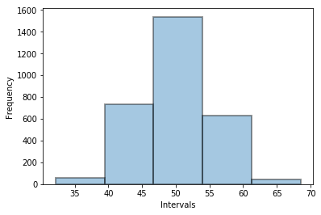

```python
sns.distplot(x, kde=False, bins=5,
             hist_kws=dict(edgecolor="k", linewidth=2))
plt.xlabel('Intervals')
plt.ylabel('Frequency')
plt.show()
```

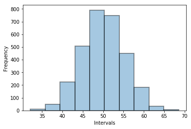

```python
sns.distplot(x, kde=False, bins=10, hist_kws=dict(edgecolor="k", linewidth=2))
plt.xlabel('Intervals')
plt.ylabel('Frequency')
plt.show()
```

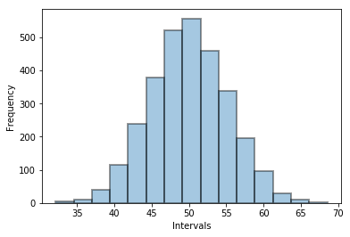

```python
sns.distplot(x, kde=False, bins=15, hist_kws=dict(edgecolor="k", linewidth=2))
plt.xlabel('Intervals')
plt.ylabel('Frequency')
plt.show()
```

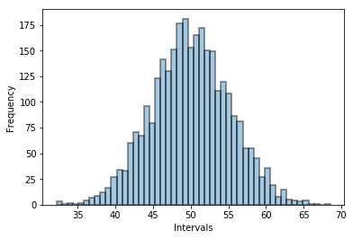

```python
sns.distplot(x, kde=False, bins=50, hist_kws=dict(edgecolor="k", linewidth=2))
plt.xlabel('Intervals')
plt.ylabel('Frequency')
plt.show()
```

```python
sns.distplot(x, kde=False, bins=30, hist_kws=dict(edgecolor="k", linewidth=2))
plt.xlabel('Intervals')
plt.ylabel('Frequency')
plt.show()
```

[output not shown]

## Relative Frequency Histogram Plot

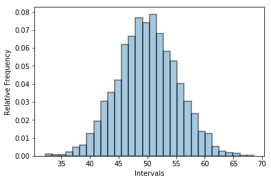

```python
sns.distplot(x, kde=False, bins=30,
             norm_hist=True,
             hist_kws=dict(edgecolor="k", linewidth=2))
plt.xlabel('Intervals')
plt.ylabel('Relative Frequency')
plt.show()
```

# Density Plot

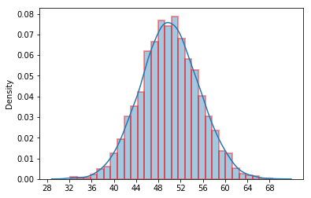

```python
sns.distplot(x, kde=True, bins=30,
             norm_hist=True,
             hist_kws=dict(edgecolor="r", linewidth=2))
plt.xticks(range(28, 70, 4))
plt.ylabel('Density')
plt.show()
```

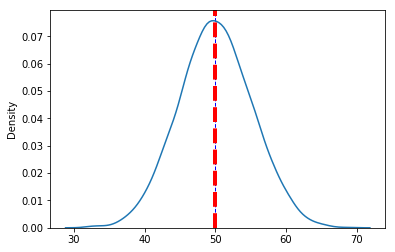

```python
plt.axvline(x.mean(), color='b', linestyle='dashed', linewidth=1)
plt.axvline(np.median(x), color='r', linestyle='dashed', linewidth=4)
sns.distplot(x, kde=True, bins=30, hist=False)
plt.ylabel('Density')
plt.show()
```

```python
np.median(x)
```

```
49.99594390121429
```

```python
np.mean(x)
```

```
50.0234060825881
```

# more examples

```python
import pandas as pd
import numpy as np
```

```python
dummy_df = pd.read_csv('dummy_data.csv')
```

```python
dummy_df
```

|  | Sno | Name | Age | Height(cm) |
| --- | --- | --- | --- | --- |
| 0 | 1 | John | 25.0 | 160.0 |
| 1 | 2 | Jimmy | 26.0 | 163.0 |
| 2 | 3 | Felicia | 28.0 | 154.0 |
| 3 | 4 | Sophia | NaN | 143.0 |
| 4 | 5 | Bob | NaN | NaN |
| 5 | 6 | Billy | 30.0 | 156.0 |
| 6 | 7 | Kate | 31.0 | 160.0 |
| 7 | 8 | Will | 29.0 | NaN |
| 8 | 9 | Scott | NaN | 148.0 |

# Reasons for missing Data

1. User did not want to fill data due to privacy issues
2. Loss of data while transferring
3. Insufficient information to fill a particular column, etc.

There can be multiple reasons for missing values in a dataset

## df.describe()

```python
dummy_df.describe()
```

|  | Sno | Age | Height(cm) |
| --- | --- | --- | --- |
| count | 9.000000 | 6.000000 | 7.000000 |
| mean | 5.000000 | 28.166667 | 154.857143 |
| std | 2.738613 | 2.316607 | 7.174691 |
| min | 1.000000 | 25.000000 | 143.000000 |
| 25% | 3.000000 | 26.500000 | 151.000000 |
| 50% | 5.000000 | 28.500000 | 156.000000 |
| 75% | 7.000000 | 29.750000 | 160.000000 |
| max | 9.000000 | 31.000000 | 163.000000 |

Here `count` returns Non-null values

```python
len(dummy_df)
```

```
9
```

## Since NaN is considered float, the data is converted to float type

```python
string_dummy_df = pd.read_csv('dummy_str_data.csv',index_col=0)
```

## df.isna() and df.notna()

```python
dummy_df.isna()
```

|  | Sno | Name | Age | Height(cm) |
| --- | --- | --- | --- | --- |
| 0 | False | False | False | False |
| 1 | False | False | False | False |
| 2 | False | False | False | False |
| 3 | False | False | True | False |
| 4 | False | False | True | True |
| 5 | False | False | False | False |
| 6 | False | False | False | False |
| 7 | False | False | False | True |
| 8 | False | False | True | False |

```python
dummy_df.notna()
```

|  | Sno | Name | Age | Height(cm) |
| --- | --- | --- | --- | --- |
| 0 | True | True | True | True |
| 1 | True | True | True | True |
| 2 | True | True | True | True |
| 3 | True | True | False | True |
| 4 | True | True | False | False |
| 5 | True | True | True | True |
| 6 | True | True | True | True |
| 7 | True | True | True | False |
| 8 | True | True | False | True |

## df.isnull()

```python
dummy_df.isnull()
```

[output not shown]

## Finding count of missing values in each column

```python
dummy_df.isnull().sum()
```

```
Sno           0
Name          0
Age           3
Height(cm)    2
dtype: int64
```

```python
string_dummy_df = pd.read_csv('dummy_str_data.csv', index_col=0)
```

```python
string_dummy_df
```

| Sno | Device_name | Device_description | Single-Use |
| --- | --- | --- | --- |
| 1 | Synringe | Used to inject medicine | True |
| 2 | Ventilator | Used to help patients breath | False |
| 3 | Surgical Gloves | NaN | True |
| 4 | Stethescopes | NaN | NaN |
| 5 | Vials container | NaN | NaN |

### Sometimes information for a column is insufficient to assign a value

# Missing data for datetime

```python
time_df = pd.read_csv('dummy_time.csv', index_col=0)
```

```python
time_df
```

|  | Sno | Name | Age | Height(cm) | birthday |
| --- | --- | --- | --- | --- | --- |
| 0 | 1 | John | 25.0 | 160.0 | 1994-01-01 |
| 1 | 2 | Jimmy | 26.0 | 163.0 | NaN |
| 2 | 3 | Felicia | 28.0 | 154.0 | 1995-01-01 |
| 3 | 4 | Sophia | NaN | 143.0 | NaN |
| 4 | 5 | Bob | NaN | NaN | 1994-01-01 |
| 5 | 6 | Billy | 30.0 | 156.0 | 1994-01-01 |
| 6 | 7 | Kate | 31.0 | 160.0 | 1990-01-01 |
| 7 | 8 | Will | 29.0 | NaN | 1991-07-01 |
| 8 | 9 | Scott | NaN | 148.0 | NaN |

```python
type(time_df['birthday'][0])
```

```
str
```

```python
time_df['birthday'] = pd.to_datetime(time_df['birthday'])
```

```python
time_df
```

|  | Sno | Name | Age | Height(cm) | birthday |
| --- | --- | --- | --- | --- | --- |
| 0 | 1 | John | 25.0 | 160.0 | 1994-01-01 |
| 1 | 2 | Jimmy | 26.0 | 163.0 | NaT |
| 2 | 3 | Felicia | 28.0 | 154.0 | 1995-01-01 |
| 3 | 4 | Sophia | NaN | 143.0 | NaT |
| 4 | 5 | Bob | NaN | NaN | 1994-01-01 |
| 5 | 6 | Billy | 30.0 | 156.0 | 1994-01-01 |
| 6 | 7 | Kate | 31.0 | 160.0 | 1990-01-01 |
| 7 | 8 | Will | 29.0 | NaN | 1991-07-01 |
| 8 | 9 | Scott | NaN | 148.0 | NaT |

```python
import numpy as np
import scipy.stats
import pandas as pd
```

```python
dummy_age = [20, 21, 24, 24, 28, 26, 19, 22, 26, 24, 21,
            19, 22, 28, 29, 6, 100, 25, 25, 28, 31]
dummy_height = [150, 151, 155, 153, 280, 160, 158, 157, 158, 145, 150,
               155, 155, 151, 152, 153, 160, 152, 157, 157, 160, 153]
dummy_df = pd.DataFrame(list(zip(dummy_age, dummy_height)),
                        columns =['Age', 'Height(cm)'])
```

```python
dummy_df
```

|  | Age | Height(cm) |
| --- | --- | --- |
| 0 | 20 | 150 |
| 1 | 21 | 151 |
| 2 | 24 | 155 |
| 3 | 24 | 153 |
| 4 | 28 | 280 |
| 5 | 26 | 160 |
| 6 | 19 | 158 |
| 7 | 22 | 157 |
| 8 | 26 | 158 |
| 9 | 24 | 145 |
| 10 | 21 | 150 |
| 11 | 19 | 155 |
| 12 | 22 | 155 |
| 13 | 28 | 151 |
| 14 | 29 | 152 |
| 15 | 6 | 153 |
| 16 | 100 | 160 |
| 17 | 25 | 152 |
| 18 | 25 | 157 |
| 19 | 28 | 157 |
| 20 | 31 | 160 |